# Final Project - Part 2

**In this part we will explore Donald Trumps tweets and answer the question -**

**Can tweets be predictive of COVID concern?**

To answer that we will explore the Donald Trump’s tweets during the concern poll.

```
## Rows: 1,549
## Columns: 7
## $ date      <date> 2020-04-04, 2020-04-04, 2020-04-04, 2020-04-04, 2020-04-04,~
## $ favorites <dbl> 0, 74661, 0, 0, 0, 0, 0, 0, 32032, 0, 0, 0, 0, 0, 0, 0, 0, 0~
## $ id        <chr> "1246434545357987842", "1246434478744047616", "1246434186942~
## $ isRetweet <lgl> TRUE, FALSE, TRUE, TRUE, TRUE, TRUE, TRUE, TRUE, FALSE, TRUE~
## $ retweets  <dbl> 4410, 10449, 3063, 3321, 2500, 108116, 4579, 1938, 6306, 363~
## $ text      <chr> "RT @IvankaTrump: Great reconnecting with President Kaljulai~
## $ Time      <chr> "16:48:47", "16:48:32", "16:47:22", "16:46:39", "16:46:31", ~
```

[output not shown]

### Step 1: clean the data

After setting the data set as a data frame and arranged the data types of the columns, lets clean the columns from Irrelevant information.

```
## Rows: 1,549
## Columns: 6
## $ date      <date> 2020-04-04, 2020-04-04, 2020-04-04, 2020-04-04, 2020-04-04,~
## $ favorites <dbl> 0, 74661, 0, 0, 0, 0, 0, 0, 32032, 0, 0, 0, 0, 0, 0, 0, 0, 0~
## $ isRetweet <lgl> TRUE, FALSE, TRUE, TRUE, TRUE, TRUE, TRUE, TRUE, FALSE, TRUE~
## $ retweets  <dbl> 4410, 10449, 3063, 3321, 2500, 108116, 4579, 1938, 6306, 363~
## $ text      <chr> " ivankatrump great reconnecting  president kaljulaid  eston~
## $ Time      <chr> "16:48:47", "16:48:32", "16:47:22", "16:46:39", "16:46:31", ~
```

Summarize of the tweets data set:

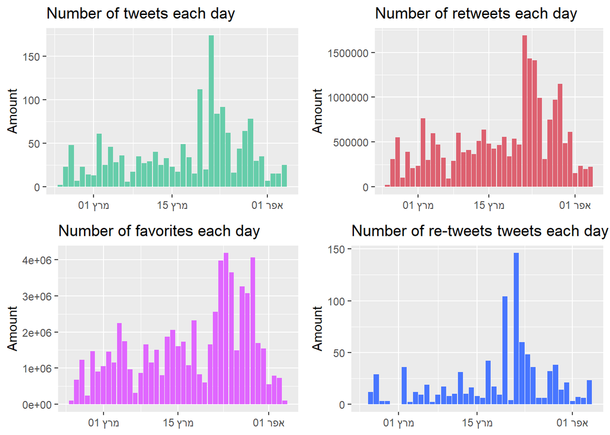

*Explanation:* we can see that all of the plots above exhibit something that look like same behavior. But this is still too raw information, we will have to keep and explore more.

so next we decided to explore the words of each tweet.

### Step 2: Exploring the words meaning

In order to understand the tweets content we chose to plot **the most common words**

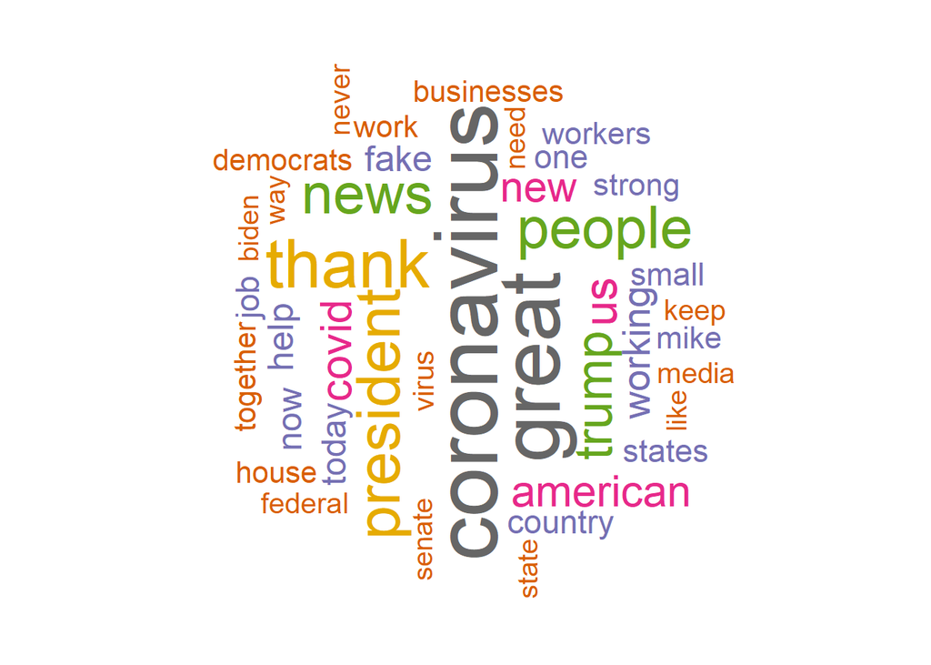

*Explanation:* *The size of each word in the plot represents its frequency ,we can see that coronavirus and great are at the highest frequency. it may imply that maybe most of his tweets were at a positive attitude toward the coronavirus.so we decided to explore the sentiments of the tweets.*

more over, there are **words with double meaning**, such as the word Trump. For such words, which we do not know the exact meaning, we decided to give them a 0 sentiment

lets see the **histogram of the words** and **their associations** with basic **emotions**:

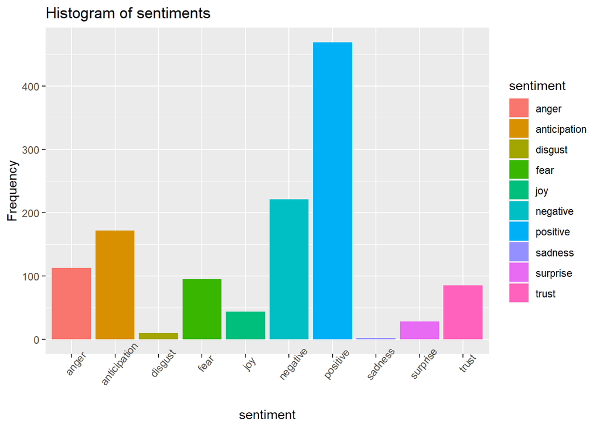

*Explanation:**We used the NRC Emotion Lexicon, it is a list in R of English words and their associations with basic emotions. It seems that most of his tweets are positive or has a good sentiment attached to it, which suppose to affect the concern of the citizens. so in order to use it in our the model we used another lexicon called AFINN that gives each emotion a numeric score*

### Step 3: calculate for each tweet his Sentiment Score

Now we want to calculate for each tweet his Sentiment Score, whether it is positive or negative. for this purpose we will use a package called AFINN, this package returns for each word a sentiment score between -5 to 5. After getting the score of each word, we will move on to calculating the average for the tweet itself - by calculating the sum sentiment of the words divided by the number of words in the tweet- the score as well can be between -5 to 5.

```
## Rows: 1,549
## Columns: 8
## $ date      <date> 2020-04-04, 2020-04-04, 2020-04-04, 2020-04-04, 2020-04-04,~
## $ favorites <dbl> 0, 74661, 0, 0, 0, 0, 0, 0, 32032, 0, 0, 0, 0, 0, 0, 0, 0, 0~
## $ isRetweet <lgl> TRUE, FALSE, TRUE, TRUE, TRUE, TRUE, TRUE, TRUE, FALSE, TRUE~
## $ retweets  <dbl> 4410, 10449, 3063, 3321, 2500, 108116, 4579, 1938, 6306, 363~
## $ text      <chr> " ivankatrump great reconnecting  president kaljulaid  eston~
## $ Time      <chr> "16:48:47", "16:48:32", "16:47:22", "16:46:39", "16:46:31", ~
## $ line      <int> 1, 2, 3, 4, 5, 6, 7, 8, 9, 10, 11, 12, 13, 14, 15, 16, 17, 1~
## $ sentiment <dbl> 3.0000000, 1.0000000, 0.0000000, 1.3333333, 2.0000000, 1.000~
```

## *Building the model*

In this part we would like to examine the extent of the impact of Trump’s tweets on the level of concern among Republicans.

while building this model we proceeded from the premise that if Trump’s tweets had an impact, then they had a greater impact on Republicans. Evidence of this can be seen in the fact that from the beginning they were much less concerned about the Corona - unlike the Democrats. Moreover, the Republican jump in the level of apprehension rose dramatically compared to the Democrats, probably when they realized that the Corona was not a laugh, but a real state of emergency.

### **step 1 :** filter all tweets unrelated to coronavirus.

for this purpose we created the vector with all the words related to the coronavirus and according to it we filtered out unrelated tweets.

To each day we add the level of daily concern that was on that day from the civiqs_poll table.

In addition, for tweets with the word “positive” that were about “tested positive for Corona” we change The sentiment to -5.

```
## Rows: 457
## Columns: 12
## $ date        <date> 2020-02-28, 2020-03-02, 2020-03-12, 2020-03-23, 2020-03-2~
## $ Time        <chr> "05:41:19", "14:09:47", "15:56:19", "03:20:08", "03:20:08"~
## $ sentiment   <dbl> -5.0000000, -5.0000000, -5.0000000, -5.0000000, -5.0000000~
## $ retweets    <dbl> 21904, 6927, 3221, 27800, 27800, 18102, 18102, 21562, 2292~
## $ text        <chr> " diagnosis positive  cnn  infected  trump derangement syn~
## $ line        <int> 1065, 999, 678, 316, 1390, 294, 1368, 1135, 1124, 1123, 11~
## $ isRetweet   <lgl> FALSE, TRUE, TRUE, FALSE, FALSE, TRUE, TRUE, FALSE, FALSE,~
## $ dem         <dbl> 35, 37, 55, 76, 76, 76, 76, 35, 35, 35, 35, 35, 35, 35, 35~
## $ rep         <dbl> -58, -57, -39, 6, 6, 6, 6, -57, -58, -58, -58, -58, -58, -~
## $ diff        <dbl> 93, 94, 94, 70, 70, 70, 70, 92, 93, 93, 93, 93, 93, 93, 93~
## $ avg_concern <dbl> -11.5, -10.0, 8.0, 41.0, 41.0, 41.0, 41.0, -11.0, -11.5, -~
## $ order       <int> 60, 110, 373, 714, 715, 754, 755, 9, 15, 16, 20, 31, 32, 3~
```

now lets see the frequency again but this time only on the tweets related to covid:

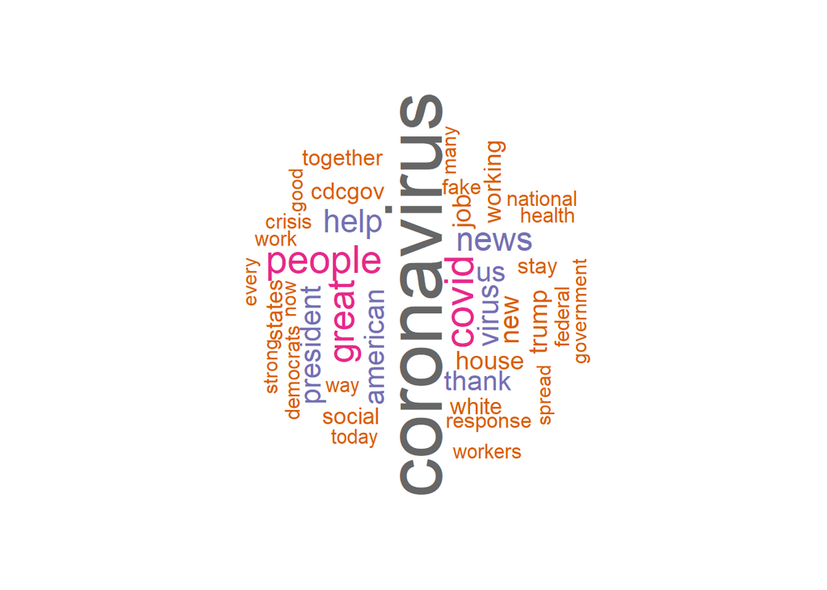

```r
freq_words<-freq_terms(text.var = tweets_about_covid$text, top = 40) # find the 40 most frequent words

set.seed(1233)
wordcloud(words = freq_words$WORD, freq = freq_words$FREQ, min.freq = 5,
          max.words=100, random.order=FALSE, rot.per=0.40,
          colors=brewer.pal(8, "Dark2"))
```

Now even more than before we see the trend of his tweets, Although he talks a lot about Corona, he does say a lot of words of encouragement , saying positive and reassuring words.

### **step 2 :** create A table of the daily averages:

1. Average daily sentiment.
2. Average daily amount of re-tweets.
3. Amount of daily tweets.
4. Amount of daily re-tweets that Trump did to others.

We have chosen to implement this table because We would like to test whether tweets have a daily impact on the concern level of the population and therefore tweet in itself does not contribute much so we would like to calculate the averages by day.

note: the mean sentiment Will receive values in percentages from -100 to 100.

```
## # A tibble: 6 x 7
##   date         rep   dem mean_sentiment mean_retweets num_isRetweet daily_tweets
##   <date>     <dbl> <dbl>          <dbl>         <dbl>         <int>        <int>
## 1 2020-02-25   -57    35        -13.3          21562              0            1
## 2 2020-02-26   -58    35          0.639        15015.             6           12
## 3 2020-02-28   -58    35        -23.3          22315.             0            7
## 4 2020-02-29   -58    36         40            19178              0            1
## 5 2020-03-01   -58    37         15.8          18464.             0            2
## 6 2020-03-02   -57    37        -22.3          12523.             4            8
```

### **step 3 :** Explore the table, before implementing the model

- Display of the **date** as **X axis** ,the **level of concern** as **Y** **axis** and **fill** of each column in the **average quantity** we calculated in the previous table - tweets_about_covid_avg

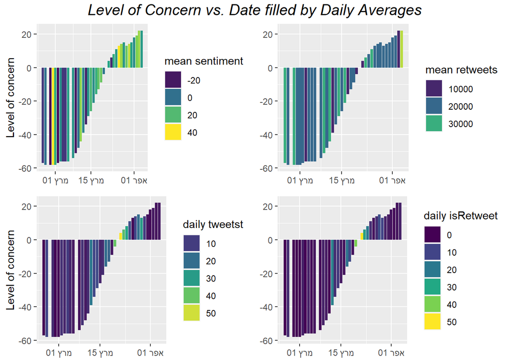

From this view we can see some interesting things:

1. When the Republican’s level of concern rises from minus to plus, Trump’s daily tweets rises as well.
2. Same for the number of re-tweets he does.
3. The trend of the daily sentiment of his tweets becomes more and more positive as the level of concern of Republicans rises.
- Now we will try to plot the data in another AVG view, maybe we will be able to extract more information - Display of the **level of concern** as **X axis** ,and the **average quantity** as **Y** **axis**

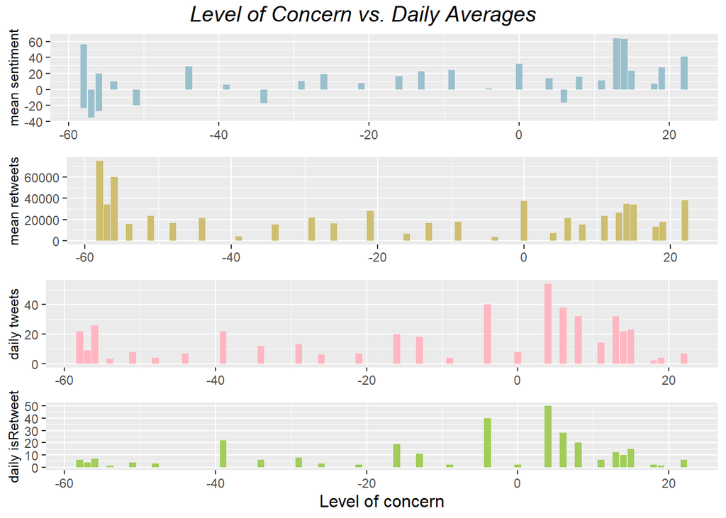

From this Plots we can see that there is **no fixed trend**.

nevertheless, it should be noted that we can see from BOTH plots, this one and the previous - that **in the** **early Corona**, when the level of concern was very low, **Trump tweeted a lot, tweeted also tweets with low sentiment score, and got a lot of re-tweets about his tweets**. And as time goes on and concern level increases, these measures decrease relatively. But with the **transition from a negative to a positive level of concern** the **measures rises rapidly** and even **higher**.

### step 4 :see if we can suggest about any linear connection

- FIRST we will make a comparison between the various measurements and the level of concern, When one view through points, and the other by drawing a line

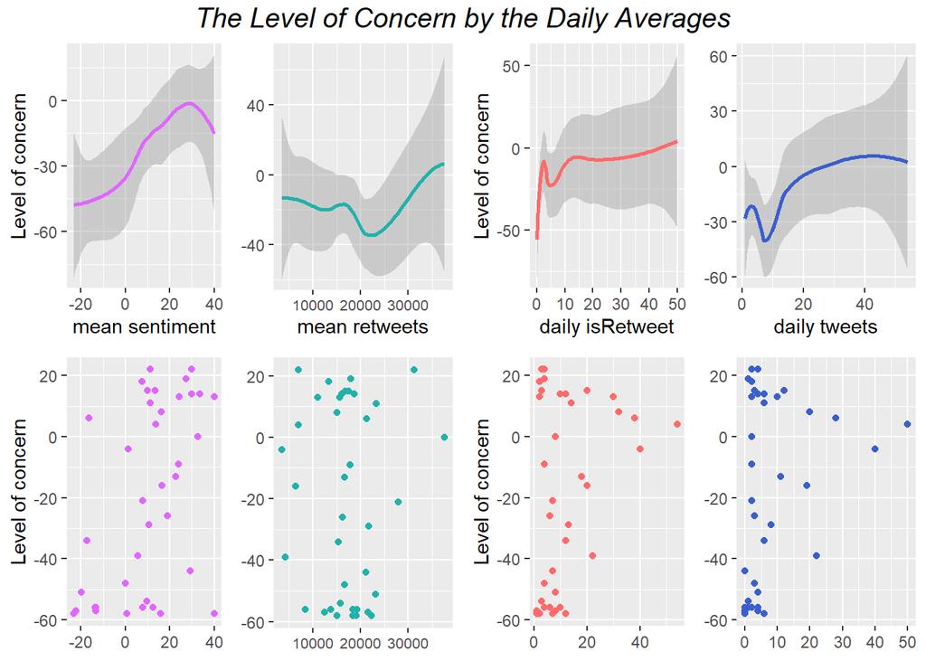

we will now move on to building the model itself.

### **step 5 :** implement the model

Divide the data into train and test

```r
model_df<-tweets_about_covid_avg%>%
  select(-dem)%>%
  rename(real_concern=rep)

#Create an initial split
set.seed(79997)
model_split <- initial_split(model_df) # prop = 3/4 by default

#Save testing, training data
model_train <- training(model_split)
model_test  <- testing(model_split)
```

Specify the model- We will decide on a **linear model**, We then **construct the recipe** of the model and select the date to be our column identifier and not as a variable. and then we will **build the work-flow**: A workflow is a container object that aggregates information required to fit and predict from a model.

The Coefficients:

```r
tweet_model<-linear_reg() %>%
  set_engine("lm")

# Build recipe
tweet_rec <- recipe(real_concern ~.  ,data = model_train)%>%
# date isn't a predictor, but keep around to ID
  update_role(date, new_role = "Date_id")#;tweet_rec

# build workflow
model_wflow<-workflow()%>%
  add_model(tweet_model)%>%
  add_recipe(tweet_rec)

tweet_fit<-model_wflow%>%
   fit(data=model_df)#;tweet_fit

tidy(tweet_fit)
```

```
## # A tibble: 5 x 5
##   term             estimate std.error statistic  p.value
##   <chr>               <dbl>     <dbl>     <dbl>    <dbl>
## 1 (Intercept)    -55.9      14.3         -3.92  0.000421
## 2 mean_sentiment   0.940     0.237        3.97  0.000364
## 3 mean_retweets    0.000867  0.000702     1.24  0.225
## 4 num_isRetweet    0.541     1.25         0.433 0.668
## 5 daily_tweets     0.621     1.08         0.574 0.570
```

In this part we will Make predictions for training data, and also for the TEST data. For each prediction we will make Pearson correlation test.

```
##
##  Pearson's product-moment correlation
##
## data:  tweet_train_pred$real_concern and tweet_train_pred$train.pred
## t = 4.8994, df = 26, p-value = 4.382e-05
## alternative hypothesis: true correlation is not equal to 0
## 95 percent confidence interval:
##  0.4312480 0.8469928
## sample estimates:
##       cor
## 0.6928528
```

```
##
##  Pearson's product-moment correlation
##
## data:  tweet_test_pred$real_concern and tweet_test_pred$test.pred
## t = 0.8616, df = 8, p-value = 0.414
## alternative hypothesis: true correlation is not equal to 0
## 95 percent confidence interval:
##  -0.4142250  0.7782404
## sample estimates:
##       cor
## 0.2914006
```

```
##       correlation
## train   0.6928528
## test    0.2914006
```

NOW we will **improve our model by create the K-fold Cross Validation** - randomly splits the data into K groups,Each time one fold will be the test data and the rest(k-1 fold) will be the train data We’ll do it k times.

```r
#Split data into folds
set.seed(35444445)
folds <- vfold_cv(model_train, v = 5) #; folds

#Fit resamples

set.seed(436)
keep_pred <- control_resamples(save_pred = TRUE, save_workflow = TRUE)

tweet_fit_rs <- model_wflow %>%
  fit_resamples(folds, control = keep_pred)
assess_resulte <- collect_predictions(tweet_fit_rs,summarize = TRUE)
```

The differences between the model results and the true value:

```
## # A tibble: 6 x 3
##   `Real Concern` Predictions Distance
##            <dbl>       <dbl>    <dbl>
## 1             18      -35.5      53.5
## 2             22      -16.7      38.7
## 3             22      -16.1      38.1
## 4             13      -18.1      31.1
## 5             19       -6.50     25.5
## 6            -34      -58.3      24.3
```

Analyze the **k-cross fold validation** **result by - Pearson correlation**

```
## # A tibble: 6 x 2
##   Fold              `Pearson correlation`
##   <chr>             <chr>
## 1 Final Correlation 0.563341398660646
## 2 Fold1             0.596226791625439
## 3 Fold2             0.386349166684773
## 4 Fold3             0.33742928938425
## 5 Fold4             0.945035599006014
## 6 Fold5             0.722957566978369
```

Plot of the results - **Predicted vs. Real Concern**

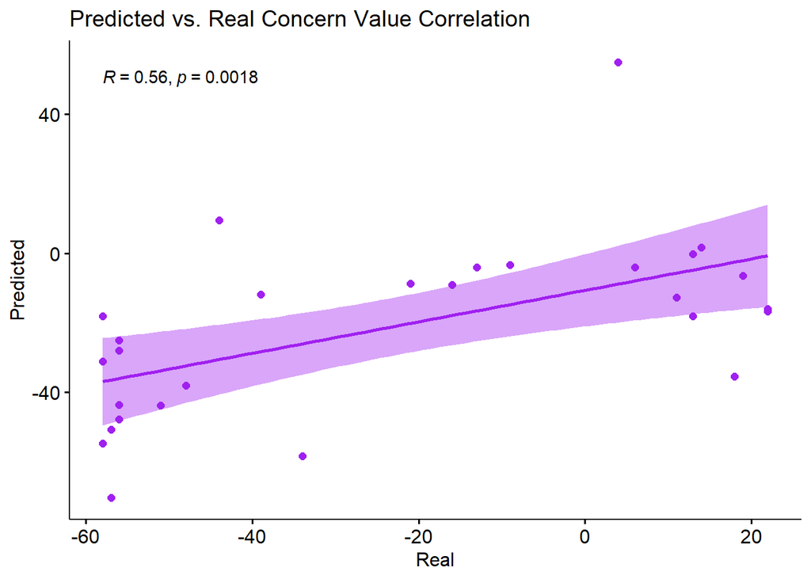